# Time Value of Money

James Woods

# Time Value of Money Goals

- Create a logical basis for comparing costs and benefits in different time periods.
- Introduce a common notation that engineers, and many economists use, for these calculations.
- Set the basis for:
  - Loans
  - Investment criteria

# Assumptions

These are demonstrably false but give us tractable methods.

- Costs and benefits of equal size have equal value in all time periods. *Can evaluate without worrying about wealth or taste changes.*
- The value of costs and benefits is independent of costs and benefits in other time periods. *No habit, addiction or hangovers.*
- Benefits offset costs. *Ever fought a parking ticket?*
- Future values are known with certainty. *Math is easy*

# What it looks like

$$\sum x_n d(n)$$

- $d(n)$ is a discounting function.
- Many are possible but only a few are time consistent.
  - $d(n) = \frac{1}{(1+r)^n}$ for discrete time.
  - $d(n) = \frac{1}{e^{r n}}$ for continuous time.

# Example of Time Inconsistency

Back in the day I did this in class with real beer. Now, it’s a policy violation.

- Chose 6-pack of beer a month and a day from now or 1 beer a month from now.
- A beer right now or a 6-pack tomorrow.
- Many of you changed your mind.

# Integer time

- Will say “Time 1”, “Time zero” because “1st time period is confusing”
- “Now” means time zero.
- Intervals are half open on the right, e.g., $[0,1)$
- Jan 1, 1908 and Dec 31, 1908 are in the same period, but Jan 1, 1909 is not, when the unit of analysis is a year.

# Notes on the interest rate

- We will treat the interest rate as a simple thing until loans.
- The rate is always just the per period rate.
- Later we will get into:
  - The nominal period.
  - Compounding period.
  - Nominal statement.
  - Effective interest rates.

# Time Consistent Integer Time Discounting

$$F= P (1+i)^N$$

Symbolic notation depends on context.

- i = The interest rate
- P = Present worth *or* some value in time zero.
- N = N time periods from Now *or* Time N
- F = Future Value *or* Present Value in time N *or* A value in time N.

We will have a full list later.

# Easy Future Value Calculation

“If you deposit $26 into an account that earns 2% a month, how much will be in the account after 500 months?”

$$F = 26(1+.02)^{500} = 518870.7975218$$

- “how much will be in the account after” is a good signal for future value.
- 100ths of a percent is more than adequate for calculations.
- Usually, cents is close enough.
- D2L questions have a tolerance.
- Most common mistakes:
  - $26(1+.02)^{500/12}$
  - $26(1+.2)^{500}$

# Easy Present Worth Calculation

“How much would you have to deposit now into an account that earns 10% per year to have 100K in 10 years?”

$$P = \frac{100K}{(1+.1)^{10}} = 38.5543289K$$

- “How much would you have to deposit now” is a present worth indicator.

# Graphical Notation

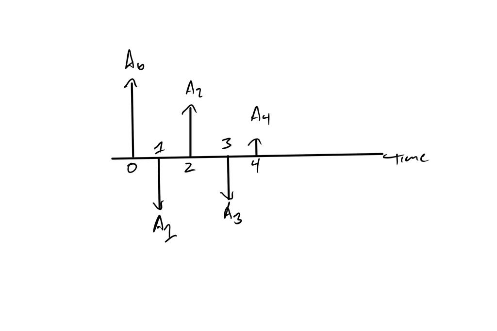

# Comments on Graphical Notation

- Up vectors are cash inflow.
- Down are cash outflow.
- Magnitude is size of cash flows.
- Cash flow in any period is $A_n$.

# Symbols Used in Symbolic (Factor) Notation

- $A_n$ = Cost or benefit in time n
- $n$ = Arbitrary time period
- $N$ = Usually but not always the last time period
- $P$ = Present worth in time zero
- $P_n$ = Present worth in time n.
- $A$ = Used in constant series to indicate same value for time 1 to N.
- $G$ = Used in linear gradient series to indicate the change in cash flow from time 1 to N.
- $g$ = Used in geometric gradient series to indicate the percent change in cash flow from time 1 to N.

# What is factor notation?

It is a functional representation of common cash flow patterns:

- Constant Series, $A_{n+1} = A_n, \forall n = 1 \dots N$
- Linear Gradient, $A_{n+1} = A_n + G, A_1=0, \forall n = 1 \dots N$
- Geometric Gradient, $A_{n+1} = A_n (1+g), \forall n = 1 \dots N$

There are other notations in use, e.g. actuarial notation.

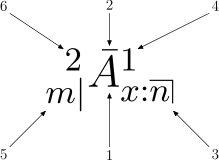

By Delimata - Own work, GFDL, https://commons.wikimedia.org/w/index.php?curid=4312450

# Factor Notation

- It is a short-hand for the closed form representations of present and future worth for the common patterns
- Example
  $$10(P|A, i= 10\%, 5) = 10 \left[ \frac{(1 + .1)^5 -1}{.1 (1+.1)^5}\right] = 37.9078677$$

The things in the parentheses are a substitute for the things in the square brackets.

# Mostly overkill for this class but …

- In the real world the problems are harder. http://web.pdx.edu/~woodsj/Teaching/PDC_PSU_revised%20final%20report_07-2009.pdf (Page 90).
- Explains the shapes better than the algebraic expression.
- Factor notation makes it easier to do parametric studies, i.e., Spider Graphs.

# Sample Spider Graph

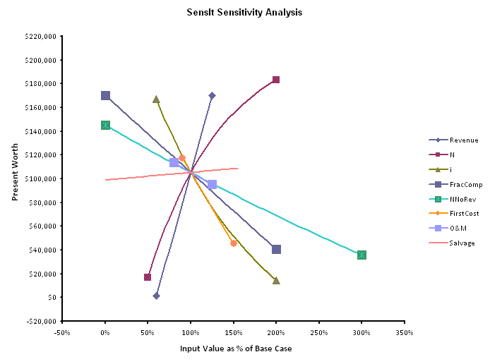

# The Key

$$Looking~For = Number(Looking~For|What~is~number, i, How ~Long)$$

- A big list is here http://ec314-pdx-edu.wikidot.com/annotated-equations-sheet
- Hint, if you know $(P|X)$, $(F|X) = (P|X) (1+r)^N$

# Wait, closed form notation?

- Remember the tricks from sequences and series? Many work for finite sequences.
- Closed form has advantage over brute force (We do that next) in that if you mess it up, it looks stupid.
- There are also tables of pre-calculated values which are useful for the PE exam.

# Present Worth Three Ways

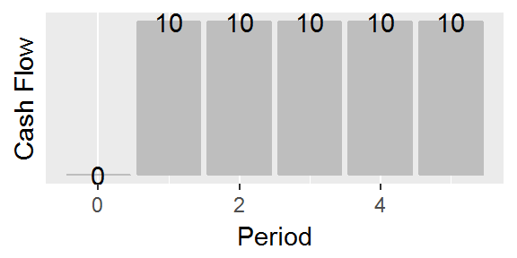

+ Brute force: $\sum_{n=1}^{5} \frac{10}{(1+.1)^n}$ + Tabular: $10 * 3.7907868$ + Closed form: $10(P|A, i = 10\%, 5) = 10 \frac{( 1+.1)^5 - 1}{.1 (1+.1)^5}$ + Either way you should get 37.9078677.

# Comments on Three Methods

- Brute force always works but when you make a mistake it hides.
- Now try $10(P|A, i =.1, 300)$ by brute force.
- Tables don’t exist for all interest rates but it was way faster on the PE, which is a speed test.
- Closed form looks stupid if you have made a mistake, but easy to make a mistake.

I tend to use brute force when it is five or fewer values.